# Project 1

2024-08-30

1. Histogram of the total number of steps taken each day
2. Mean and median number of steps taken each day
3. Time series plot of the average number of steps taken
4. The 5-minute interval that, on average, contains the maximum number of steps
5. Code to describe and show a strategy for imputing missing data
6. Histogram of the total number of steps taken each day after missing values are imputed
7. Panel plot comparing the average number of steps taken per 5-minute interval across weekdays and weekends
8. All of the R code needed to reproduce the results (numbers, plots, etc.) in the report

##Step 2 ##Histogram of the total number of steps taken each day

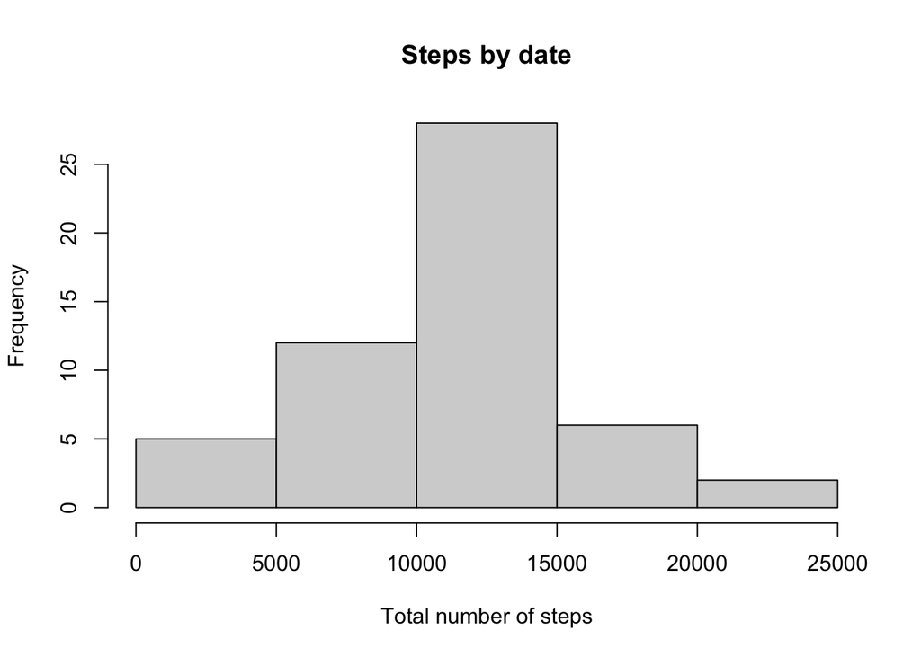

```r
hist(tapply(activity$steps, activity$date, sum), main = 'Steps by date',  xlab = 'Total number of steps')
```

##Step 3 ##Mean and median number of steps taken each day

```r
activity |>
  group_by(date) |>
  summarize(Mean = mean(steps, na.rm = T), Median = median(steps, na.rm = T)) -> Mean_median_steps_by_date
Mean_median_steps_by_date
```

```
## # A tibble: 61 × 3
##    date          Mean Median
##    <date>       <dbl>  <dbl>
##  1 2012-10-01 NaN         NA
##  2 2012-10-02   0.438      0
##  3 2012-10-03  39.4        0
##  4 2012-10-04  42.1        0
##  5 2012-10-05  46.2        0
##  6 2012-10-06  53.5        0
##  7 2012-10-07  38.2        0
##  8 2012-10-08 NaN         NA
##  9 2012-10-09  44.5        0
## 10 2012-10-10  34.4        0
## # ℹ 51 more rows
```

##Step 4 ##Time series plot of the average number of steps taken

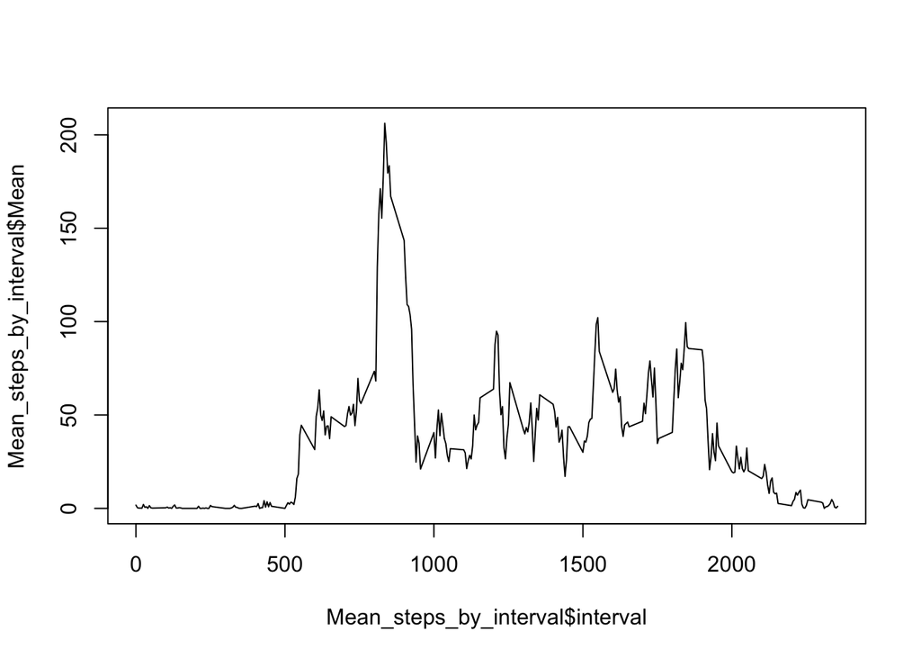

```r
activity |>
  group_by(interval) |>
  summarize(Mean = mean(steps, na.rm = T)) -> Mean_steps_by_interval
plot(Mean_steps_by_interval$interval, Mean_steps_by_interval$Mean, type = 'l')
```

##Step 5 ##The 5-minute interval that, on average, contains the maximum number of steps

```r
Mean_steps_by_interval$interval[which.max(Mean_steps_by_interval$Mean)]
```

```
## [1] 835
```

##Step 6 ##Code to describe and show a strategy for imputing missing data

```r
# Value to be imputed for NA
moddf2 <- activity |>
        group_by(date) |>
        mutate(mean=mean(steps))
imputed<-moddf2$mean[is.na(moddf2$mean)!= TRUE]

# Replace NA to mean of interval value
replace_activity <- activity |>
                    group_by(date) |>
                    mutate(replaced_steps=ifelse(is.na(steps),yes = imputed,no=steps))
```

##Step 7 ##Histogram of the total number of steps taken each day after missing values are imputed

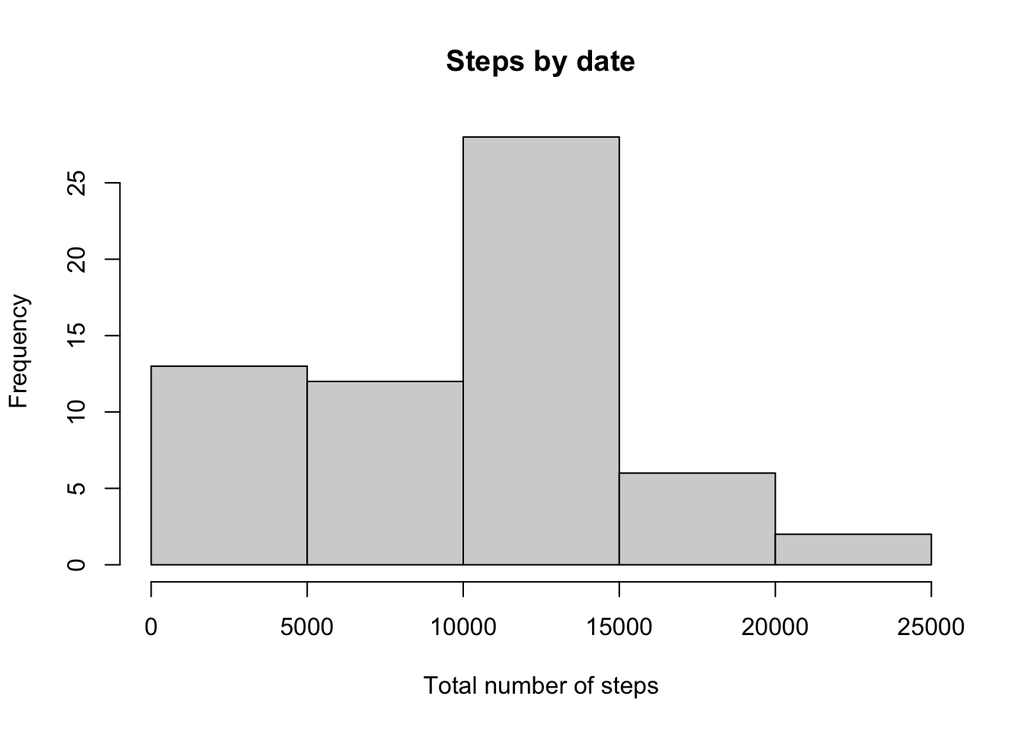

```r
hist(tapply(replace_activity$replaced_steps, replace_activity$date, sum), main = 'Steps by date',  xlab = 'Total number of steps')
```

##Step 8 ##Panel plot comparing the average number of steps taken per 5-minute interval across weekdays and weekends

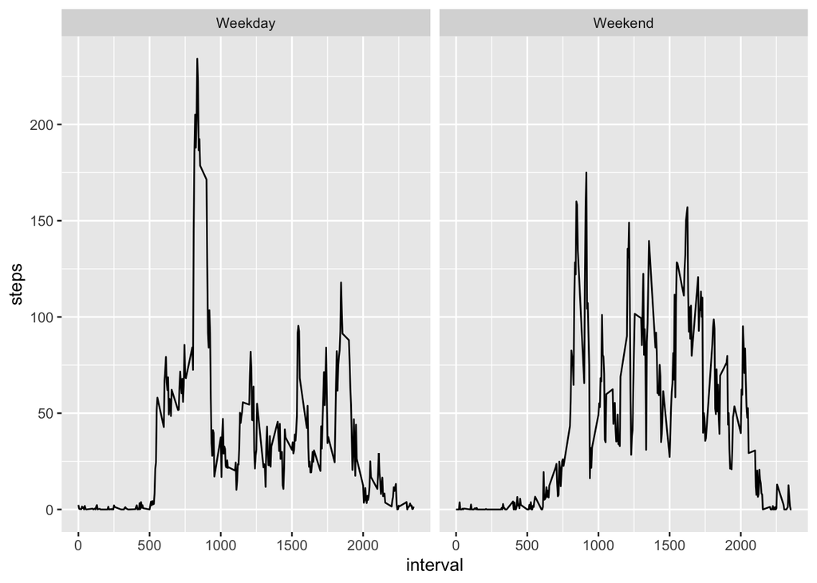

```r
activity$date <- as.Date(strptime(activity$date, format="%Y-%m-%d"))
activity$datetype <- sapply(activity$date, function(x) {
  if (weekdays(x) == "Saturday" | weekdays(x) =="Sunday")
  {y <- "Weekend"}
  else
  {y <- "Weekday"}
  y
})

activity_by_date <- aggregate(steps~interval + datetype, activity, mean, na.rm = TRUE)
g<-qplot(x=interval,y=steps,data = activity_by_date,facets = .~datetype,geom = "line",group=1)
print(g)
```